# Plant IMage Analysis

# Counting crop grains

Here, we will count the grains in the image `soybean_touch.jpg`. This image has a cyan background and contains 30 soybean grains that touch each other.

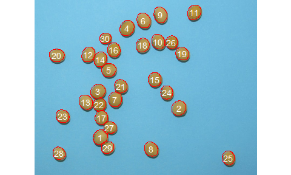

```r
soy <- image_pliman("soybean_touch.jpg")
plot(soy)

# Count the objects in the image
grains <- analyze_objects(soy)

# Draws the object id (by default)
plot_measures(grains)
```

# Disease severity

## Using image indexes

To compute the percentage of symptomatic leaf area you can use the `measure_disease()` function you can use an image index to segment the entire leaf from the background and then separate the diseased tissue from the healthy tissue. Alternatively, you can provide color palette samples to the `measure_disease()` function. In this approach, the function fits a general linear model (binomial family) to the RGB values of the image. It then uses the color palette samples to segment the lesions from the healthy leaf.

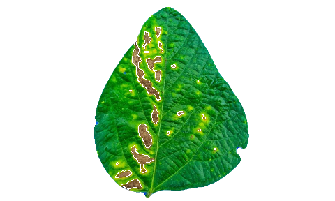

```
# $severity
#    healthy symptomatic
# 1 92.62721    7.372791
#
# $shape
# NULL
#
# $statistics
# NULL
#
# attr(,"class")
# [1] "plm_disease"
```

```r
img <- image_pliman("sev_leaf.jpg")
# Computes the symptomatic area
measure_disease(img = img,
                index_lb = "B", # to remove the background
                index_dh = "NGRDI", # to isolate the diseased area
                threshold = c("Otsu", 0), # You can also use the Otsu algorithm in both indexes (default)
                plot = TRUE)
```

## Interactive disease measurements

An alternative approach to measuring disease percentage is available through the `measure_disease_iter()` function. This function offers an interactive interface that empowers users to manually select sample colors directly from the image. By doing so, it provides a highly customizable analysis method.

One advantage of using `measure_disease_iter()` is the ability to utilize the “mapview” viewer, which enhances the analysis process by offering zoom-in options. This feature allows users to closely examine specific areas of the image, enabling detailed inspection and accurate disease measurement.

```r
img <- image_pliman("sev_leaf.jpg", plot = TRUE)
measure_disease_iter(img, viewer = "mapview")
```

# RGB values for objects

The function `analyze_objects()` can also be used to get the Red Green and Blue (RGB) -or any other image index- for objects in an image. To do that, use the argument `object_index`.

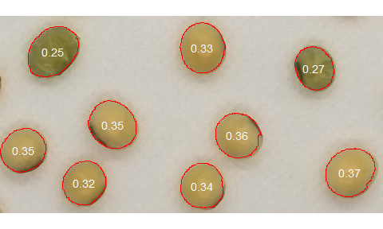

```r
img <- image_pliman("soy_green.jpg")
# Segment the foreground (grains) using the normalized blue index
# Shows the average value of the blue index in each object

rgb <-
  analyze_objects(img,
                  object_index = "B",
                  pixel_level_index = TRUE)
# Plots the B index for each grain
plot_measures(rgb, measure = "B")
```

# Getting help

If you come across any clear bugs while using the package, please consider filing a minimal reproducible example on [github](https://github.com/TiagoOlivoto/pliman/issues). This will help the developers address the issue promptly.

Suggestions and criticisms aimed at improving the quality and usability of the package are highly encouraged. Your feedback is valuable in making {pliman} even better!

# A little bit more!

For more examples on how to utilize {pliman} for analyzing plant images, you can visit this [this link](https://tiagoolivoto.github.io/paper_pliman/code.html). On that page, you will find downloadable source code and images that can be used for your analysis. Additionally, you can watch a talk about {pliman} (in Portuguese) [here](https://www.youtube.com/watch?v=ElvUVlPocgA) to gain more insights and tips on using the package effectively.

Get ready with your project and let {pliman} shine with its image analysis capabilities!